# Week 6: Intro to Stan

PS 818 - Statistical Models

Anton Strezhnev

strezhnev@wisc.edu

University of Wisconsin-Madison

October 6, 2025

$$\require{cancel}
\DeclareMathOperator*{\argmin}{arg\,min}$$

$$\DeclareMathOperator*{\argmax}{arg\,max}$$

# Previously

- **Bayesian inference**
  - Parameters of interest are **random** variables (randomness captures “beliefs”)
  - Contrast with **frequentist** approach: parameter is fixed, data is random
  - **Bayesian** target of inference is the **posterior** distribution $p(\theta | \mathbf{Y})$
  - **Bernstein-von Mises theorem** - in large samples, bayesian posterior distributions approximate MLE sampling distributions.
- **Posterior inference**
  - Some posteriors have an analytically tractable form – typically we get this through the use of **conjugate priors**
  - Most posterior distributions are not analytically tractable – need to do inference **numerically** via sampling
  - **Markov Chain-Monte Carlo** - Construct a chain of samples that converge to a stationary distribution which happens to be the target posterior.
  - **Metropolis-Hastings** - An algorithm to generate a chain that approximates a target posterior
  - **Gibbs Sampling** - Special case of MH where samples are from alternating **conditional distributions**

# This week

- **MCMC via Stan**
  - Stan is a C++ library for specifying statistical models and conducting inference via **Hamiltonian MCMC**
  - R has *bindings* to Stan via the `rstan` package
  - Extremely flexible - any model that you can write can be translated to machine code an estimated using an algorithm that converges much more quickly than conventional MH
- **Model diagnostics**
  - How do we know if our model is good?
  - Posterior predictive checks
  - Cross-validation, Leave-one-out CV
- **(Next week): Multilevel models**
  - What happens when we impose further structure on parameters (e.g. random slopes and intercepts)
  - Choices of **hyperpriors** governs the extent of **partial pooling**

# Gibbs Sampling Continued

# Aside: Conditional distributions

- When we discussed **Gibbs Sampling** we illustrated the significant gains we can obtain over naive Metropolis-Hastings
  - Faster convergence, less correlation between samples
- These gains come from being able to derive the form of the conditional distribution of $\theta_k$ given the other parameters $\theta_{-k}$ as well as the data $\mathbf{Y}$.
- Deriving these conditionals often relies on inspecting a density that is proportional to the conditional density and recognizing its form.
  - To do this, it’s useful to remember the connection between **conditional** densities and **joint** densities as well as how **joint** densities factor.

# Aside: Conditional distributions

- Consider our **normal regression** example, we want to obtain samples from the joint density $f(\beta, \sigma^2 | \mathbf{Y})$
- To do so, we need the conditionals $f(\beta | \mathbf{Y}, \sigma^2)$ and $f(\sigma^2 | \mathbf{Y}, \beta)$.
- Can we derive them (or at least their distributional forms?)
- Remember the definition of a conditional expectation: joint divided by marginal

  $$f(\beta | \mathbf{Y}, \sigma^2) = \frac{f(\beta, \sigma^2 | \mathbf{Y})}{f(\sigma^2 | \mathbf{Y})}$$
- Since we treat $\sigma^2$ here as a constant, we can write

  $$f(\beta | \mathbf{Y}, \sigma^2) \propto f(\beta, \sigma^2 | \mathbf{Y}) \equiv f(\mathbf{Y} | \beta, \sigma^2)f(\beta, \sigma^2)$$
- where the last part follows from the definition of the posterior

# Aside: Conditional distributions

- Next, remember how distributions factor

  $$f(\beta, \sigma^2) = f(\beta | \sigma^2)f(\sigma^2)$$
- If $\beta$ and $\sigma^2$ are marginally independent,then the joint distribution factors into the **marginals**
  - But even if they’re not independent, we can always factor into a product of conditionals
- So we have

  $$f(\beta | \mathbf{Y}, \sigma^2) \propto f(\mathbf{Y} | \beta, \sigma^2)f(\beta | \sigma^2) f(\sigma^2)$$
- Again, $\sigma^2$ is a constant here, so that last density drops as a multiplicative constant

  $$f(\beta | \mathbf{Y}, \sigma^2) \propto f(\mathbf{Y} | \beta, \sigma^2)f(\beta | \sigma^2)$$

# Aside: Conditional distributions

- Remember, our special case of the normal model from last week assumed that $\beta$ and $\sigma^2$ are marginally independent

  $$f(\beta | \mathbf{Y}, \sigma^2) \propto f(\mathbf{Y} | \beta, \sigma^2)f(\beta)$$
- And independence of observations gives

  $$f(\beta | \mathbf{Y}, \sigma^2) \propto \bigg[\prod_{i=1}^N f(Y_i | \beta, \sigma^2)\bigg]f(\beta)$$
- The key is finding densities that are given by our model description - now all of these factors are known

  $$f(\beta | \mathbf{Y}, \sigma^2) \propto \bigg[\prod_{i=1}^N \underbrace{f(Y_i | \beta, \sigma^2)}_{\text{Normal}(X_i^{\prime}\beta, \sigma^2)}\bigg]\times\underbrace{f(\beta)}_{\text{Normal}(b_0, B_0^{-1})}$$
- One useful property from probability theory is that products of two normal PDFs are proportional to the normal PDF
  - So $\beta | \mathbf{Y}, \sigma^2$ is normal!

# Normal-normal conjugacy

- To illustrate why the normal is conjugate to the normal, let’s plug in the densities and drop multiplicative constants

  $$f(\beta | \mathbf{Y}, \sigma^2) \propto \bigg[\prod_{i=1}^N \exp\bigg(-\frac{(Y_i - X_i^\prime \beta)^2}{2\sigma^2}\bigg)\bigg]\times \exp\bigg(-\frac{1}{2}(\beta - b_0)^{\prime}B_0(\beta - b_0)\bigg)$$
- Using properties of the products of exponentials

  $$f(\beta | \mathbf{Y}, \sigma^2) \propto \exp\bigg(-\frac{\sum_{i=1}^n(Y_i - X_i^\prime \beta)^2}{2\sigma^2}\bigg)\times \exp\bigg(-\frac{1}{2}(\beta - b_0)^\prime B_0(\beta - b_0)\bigg)$$
- We can write the first term as a quadratic form where $\Sigma$ is a matrix with diagonal terms $\sigma^2$

  $$f(\beta | \mathbf{Y}, \sigma^2) \propto \exp\bigg(-\frac{1}{2}(\mathbf{Y} - X\beta)^\prime \Sigma^{-1}(\mathbf{Y} - X\beta)\bigg)\times \exp\bigg(-\frac{1}{2}(\beta - b_0)^\prime B_0(\beta - b_0)\bigg)$$

# Normal-normal conjugacy

- Expand the quadratic form, drop terms that only contain $Y$,and use the fact that $\Sigma^{-1}$ is symmetric.

  $$f(\beta | \mathbf{Y}, \sigma^2) \propto \exp\bigg(-\frac{1}{2}\bigg[\beta^\prime \mathbf{X}^\prime \Sigma^{-1} \mathbf{X}\beta + 2\mathbf{Y}^\prime \Sigma^{-1} \mathbf{X}\beta\bigg]\bigg)\times \exp\bigg(-\frac{1}{2}(\beta - b_0)^\prime B_0(\beta - b_0)\bigg)$$
- Since $\Sigma^{-1}$ is a diagonal matrix and using the properties of transposes, we can write the above as:

  $$f(\beta | \mathbf{Y}, \sigma^2) \propto \exp\bigg(-\frac{1}{2\sigma^2}\bigg[\beta^\prime \mathbf{X}^\prime \mathbf{X}\beta + 2\beta^\prime \mathbf{X}^\prime \mathbf{Y} \bigg]\bigg)\times \exp\bigg(-\frac{1}{2}(\beta - b_0)^\prime B_0(\beta - b_0)\bigg)$$
- A well known result (completing the square) allows us to factor that expression into a familiar quadratic form with $\beta$ and a term that again drops out as a constant (depends only on $\mathbf{X}$ and $\mathbf{Y}$)

  $$f(\beta | \mathbf{Y}, \sigma^2) \propto \exp\bigg(-\frac{1}{2\sigma^2}[\beta - (\mathbf{X}^\prime\mathbf{X})^{-1}(\mathbf{X}^\prime\mathbf{Y})]^\prime(\mathbf{X}^\prime\mathbf{X})[\beta - (\mathbf{X}^\prime\mathbf{X})^{-1}(\mathbf{X}^\prime\mathbf{Y})]\bigg)\times \exp\bigg(-\frac{1}{2}(\beta - b_0)^\prime B_0(\beta - b_0)\bigg)$$

# Normal-normal conjugacy

- Now we can combine likelihood and prior using the properties of the sums of quadratic forms (and again dropping constants of proportionality).

  $$f(\beta | \mathbf{Y}, \sigma^2) \propto \exp\bigg(-\frac{1}{2\sigma^2}[\beta - (\mathbf{X}^\prime\mathbf{X} + B_0)^{-1}(B_0b_0 + \mathbf{X}^\prime\mathbf{Y} )]^\prime(\mathbf{X}^\prime\mathbf{X} + B_0)[\beta - (\mathbf{X}^\prime\mathbf{X} + B_0)^{-1}(B_0b_0 + \mathbf{X}^\prime\mathbf{Y})]\bigg)$$
- Inspecting this kernel, we can recognize the posterior mean and posterior variance-covariance matrix.
- **Variance-Covariance matrix**

  $$V = \sigma^2(B_0 + \mathbf{X}^{\prime}\mathbf{X})^{-1}$$
- and **Mean**

  $$\mu = (B_0 + \mathbf{X}^{\prime}\mathbf{X})^{-1}(B_0b_0 + \mathbf{X}^{\prime}\mathbf{Y})$$
- Note again how the posterior distribution combines the data and the prior with the influence of the prior diminishing as the number of observations grows.
- $\sigma^2$ also has a conditional that is inverse-gamma with a similar intuition for the updates, but we’ll skip that and keep our random walk sampler for $\sigma^2$ to illustrate the “Metropolis-in-Gibbs” approach.

# Revisiting: Predicting Elections

```r
# Load the data
elections <- read_csv("data/us-house-wide.csv")

# Aggregate the house data to counties
elections_county <- elections %>% group_by(fipscode) %>% summarize(state=state[1], county=county[1],
                                                                   total.votes = sum(total.votes),
                                                                   dem = sum(dem))

# Merge in 2015 Presidential
pres_2016 <- read_csv("data/clinton_2016_vote.csv")
elections_county <- elections_county %>% left_join(pres_2016 %>% dplyr::select(county_fips, candidatevotes, totalvotes),
                                                   by=c(fipscode="county_fips"))

# Generate vote shares
elections_county$dem2018 <- elections_county$dem/elections_county$total.votes
elections_county$dem2016 <- elections_county$candidatevotes/elections_county$totalvotes

# Drop missing
elections_county <- elections_county %>% filter(!is.na(dem2018)&!is.na(dem2016))
```

# Gibbs and Metropolis

- Set up the regression

```r
X_mat <- model.matrix(dem2018 ~ dem2016, data=elections_county)
Y <- elections_county$dem2018
K <- ncol(X_mat) # Number of beta parameters
```

- Set up a diffuse prior

```r
beta_0 <- rep(0, K)
B_0 <- diag(rep(1/9, K))
B_inv_0 <- solve(B_0)
c_0 = 0.001
d_0 = 0.001
```

- Set up the MCMC

```r
M <- 40000  # Number of MCMC samples
burnin <- 5000
beta_mcmc <- matrix(nrow = M, ncol=K) # Vector to store our samples
beta_mcmc[1,] <- c(0,1) # Pick a starting value
sigma_mcmc <- rep(NA, M)
sigma_mcmc[1] <- 1
```

# Gibbs and Metropolis

- Write some functions to evaluate the likelihood and priors

```r
log_lik_norm <- function(b, sigma, Y, X){
  linpred <- X%*%b
  sum(dnorm(Y, mean=linpred, sd=sigma, log=T))
}
```

# Gibbs and Metropolis

```r
set.seed(60637)
for (i in 1:(M-1)){ # For i in 1:(M-1)
  ## Beta
    ## Gibbs Step!
    var_b <- solve(t(X_mat)%*%X_mat + B_0)
    mean_b <- var_b%*%(B_0%*%beta_0 + t(X_mat)%*%Y)
    beta_mcmc[i+1,] <-  mvtnorm::rmvnorm(1, mean  = mean_b, sigma=(sigma_mcmc[i]^2)*var_b)

  ## Sigma
    ## Step 1 - Proposal
    sigma_log <- rnorm(1, mean = log(sigma_mcmc[i]), sd=.01)
    sigma_star <- exp(sigma_log)

    ## Step 2 - Accept/Reject
    lik_star_sigma <- log_lik_norm(beta_mcmc[i+1,], sigma_star, Y, X_mat)
    lik_current_sigma <- log_lik_norm(beta_mcmc[i+1,], sigma_mcmc[i], Y, X_mat)
    # The trick here is independence - otherwise if \sigma^2 appeared in the prior for \beta, we'd need another term
    prior_star_sigma <- log(MCMCpack::dinvgamma(sigma_star^2, shape = c_0/2, scale = d_0/2))
    prior_current_sigma  <-  log(MCMCpack::dinvgamma(sigma_mcmc[i]^2, shape = c_0/2, scale = d_0/2))

    ## Accept/reject
    ar_sigma <- exp(lik_star_sigma + prior_star_sigma - lik_current_sigma - prior_current_sigma)
    accept_sigma <- rbinom(1,1,min(1,ar_sigma))
    sigma_mcmc[i+1] <- sigma_star*accept_sigma + sigma_mcmc[i]*(1-accept_sigma)

}
beta_mcmc_use <- beta_mcmc[burnin:M,] # Toss our burn-in period
```

# Convergence

- $\beta_1$

```r
plot(y=beta_mcmc_use[,2], x=1:length(beta_mcmc_use[,2]), xlab="Iteration", ylab="beta_1", type="l")
```

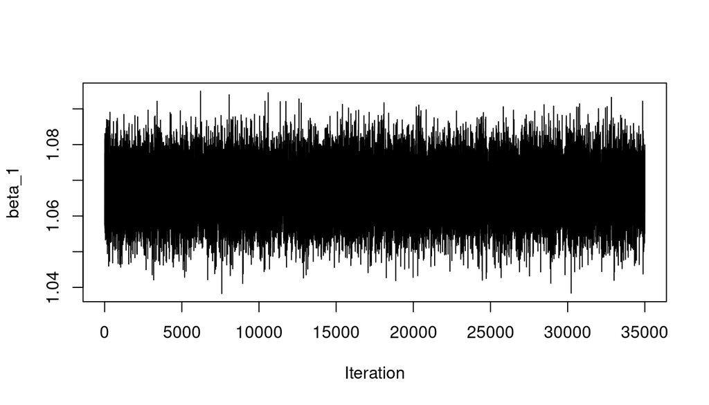

- Much better than before with the naive “random walk” proposal distribution.

# Results

$\beta_1$

```r
beta_mcmc_out <- as.data.frame(beta_mcmc_use)
colnames(beta_mcmc_out) <- c("Intercept", "dem2016")
beta_mcmc_out %>% ggplot(aes(x=dem2016)) +  theme_bw() + xlim(1.02, 1.10) + xlab("2016 Democratic Presidential Vote") + geom_histogram(aes(y=after_stat(density)), bins=50)
```

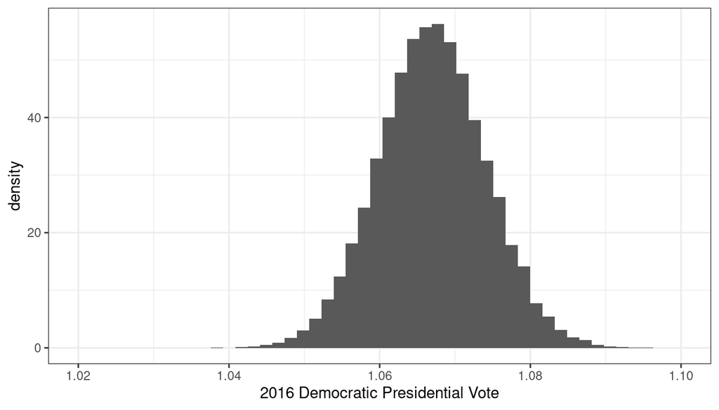

# Summaries

- Posterior means and 95% credible intervals

```r
summary_results <- data.frame(variable = c("Intercept", "dem2016"), pm = colMeans(beta_mcmc_out),
                              ci95_lower = apply(beta_mcmc_out, 2, function(x) quantile(x, .025)),
                              ci95_upper = apply(beta_mcmc_out, 2, function(x) quantile(x, .975)))

summary_results
```

```
           variable    pm ci95_lower ci95_upper
Intercept Intercept 0.031     0.0261     0.0359
dem2016     dem2016 1.067     1.0530     1.0810
```

# Intro to Stan/HMC

# Overview of HMC

- **Hamiltonian Monte Carlo** is a method that improves upon the conventional Metropolis-Hastings algorithm by improving the **proposals** such that they are accepted with very high probability
- The method draws on a theoretical core from differential geometry, but it’s not strictly necessary to get the intuition for it.
  - [Betancourt (2014) “A Conceptual Introduction to Hamiltonian Monte Carlo”](https://arxiv.org/abs/1701.02434) is a good overview for applied researchers (familiarity with statistics but not physics)
- MCMC (ideally) works by 3 general phases
  1. From the starting values, reach the “typical set” of parameter values that occupy most of the posterior density mass
  2. The MCMC traverses the “typical set” of values once.
  3. Repeated traversals improve the quality of the MCMC approximation.
- Problems arise when Markov Chains
  1. Don’t traverse high density parts of the posterior
  2. Get *stuck* in parts of the density.

# Overview of HMC

- Typical distributions for $Q$ are random walks
  - In high dimensions, these tend to be **bad** proposals.
- One solution is to choose a low variance for the random walk
  - This leads to high autocorrelation in the proposals

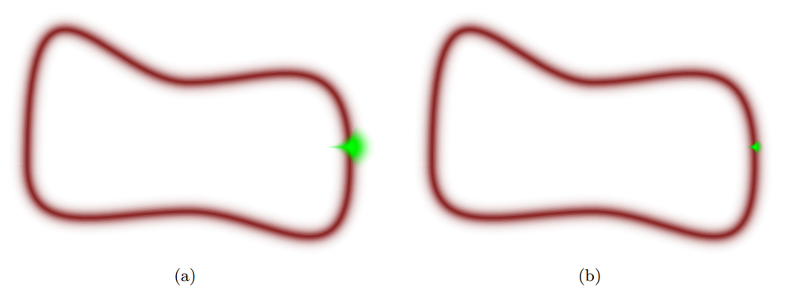

# Overview of HMC

- What if we could come up with a “direction” to point our proposal (or sequence of proposals) that stayed in the “typical set”
  - Is there another way to get proposals with an acceptance probability of 1 besides Gibbs sampling?

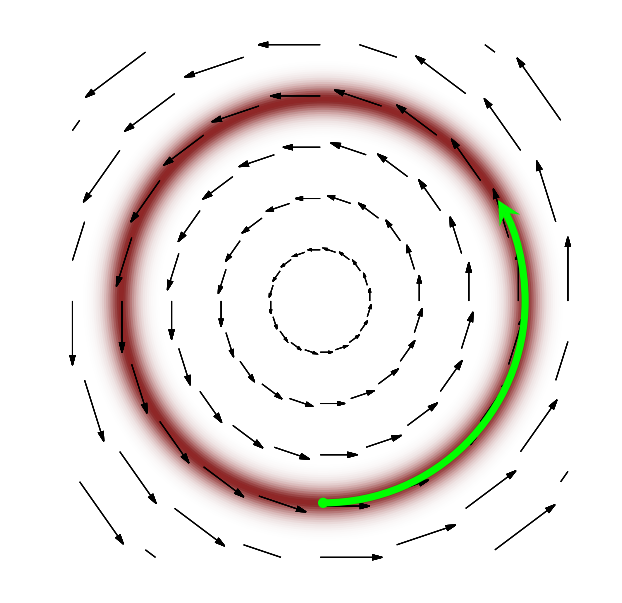

# Overview of HMC

- Instead of sampling just from $p(\theta | \mathbf{Y})$, we’ll introduce a set of auxiliary variables $\rho$ and sample from the joint density $p(\rho, \theta | \mathbf{Y})$.
  - We’ll generate samples of $\rho$ and “evolve” $\theta$ in a particular manner.
- That density factors such that if we integrated out the auxiliary variables, we’d get the target.

  $$p(\rho, \theta | \mathbf{Y}) = p(\rho | \theta, \mathbf{Y})p(\theta | \mathbf{Y})$$
- And we’ll typically pick a distribution on $\rho$ that is independent of the parameter values.

  $$p(\rho, \theta | \mathbf{Y}) = p(\rho)p(\theta | \mathbf{Y})$$
- If I propose $\rho^*$ randomly, how do I determine $\theta^*$ such that $p(\rho, \theta | \mathbf{Y}) = p(\rho^*, \theta^* |\mathbf{Y})$ and my acceptance probability is $1$?

# Overview of HMC

- The joint density defines a Hamiltonian $H(\rho, \theta)$ which characterizes the target distribution - in the physics analogy, this is the “total energy” of our system.

  $$\begin{align*}H(\rho, \theta) &= -\log(p(\rho, \theta | \mathbf{Y}))\\
  &= - \log(p(\rho)) - \log(p(\theta | \mathbf{Y}))\\
  &= T(\rho) + V(q)\end{align*}$$
- Energy is conserved in this system, so if we randomly choose $\rho$ and then jointly evolve $\rho$ and $\theta$ according to **Hamilton’s equations**, we’ll explore a space of proposals that are guaranteed to accept.

  $$\begin{align*}\frac{d\theta}{dt} &= + \frac{\partial H}{\partial \rho} = \frac{\partial{T}}{\partial{\rho}}\\
  \frac{d\rho}{dt} &= -\frac{\partial H}{\partial \theta} = -\frac{\partial V}{\partial{\theta}}\end{align*}$$

# Overview of HMC

- **HMC Algorithm** (in Stan)
  - Propose $\rho^* \sim \text{MultivariateNormal}(0, M)$
  - Evolve the joint system of $\rho^*, \theta^*$ using Hamilton’s equations for some number of steps
  - Metropolis accept/reject the proposed new set of values.

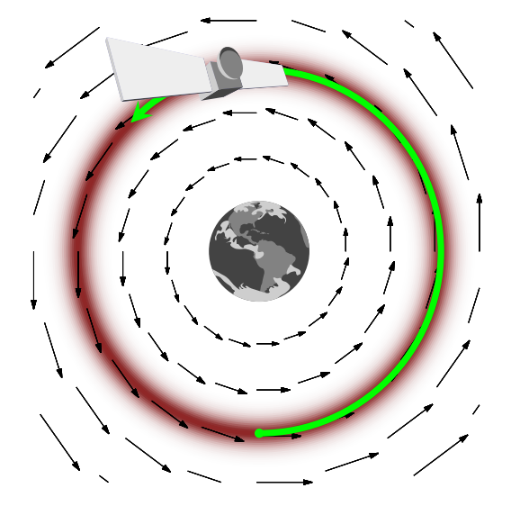

# Overview of HMC

- **Central intuitions**
  - Hamiltonian Monte Carlo is designed to generate proposals with **high acceptance probability**
  - These proposals require knowing the **gradient** of the unnormalized posterior with respect to the parameters
- Analytical computation of the gradient is tedious
  - Numeric computation can be unstable.
  - Many modern techniques use **automatic** differentiation
- **Intuition**: Decompose the unnormalized posterior into a series of elementary arithmetic operations and functions where derivatives are trivially known
  - Use the **chain rule** to construct the gradient from the component functions + their derivatives.
- **Downside**: Can’t use HMC for *discrete* parameters (but can often just marginalize those out).

# Overview of Stan

- `Stan` is a C++ library that implements a version of Hamiltonian Monte Carlo
  - Latest iteration of the “model-to-MCMC” libraries like `JAGS` and `BUGS` (which are gibbs samplers)
- Key Features
  1. Language agnostic - has bindings in R, Python, Julia, STATA, etc…
  2. Fast run-time
  3. High-level language for specifying models to be converted to C++ code.
- Complications
  - Running Stan requires you to have the ability to compile C++ code locally
  - Stan also requires learning a slightly new syntax

# Stan resources

- [Installation Quick Start Guide](https://github.com/stan-dev/rstan/wiki/RStan-Getting-Started)
- [Stan User Guide](https://mc-stan.org/docs/stan-users-guide/index.html)
- [Stan Reference Manual](https://mc-stan.org/docs/stan-users-guide/index.html)
- [Stan Functions Reference](https://mc-stan.org/docs/functions-reference/index.html)
- [A good model building tutorial for social scientists by Jim Savage](https://rpubs.com/jimsavage/stanintro)

# Installing Rstan

- We’re working with R, so we’ll be using the `Rstan` interface to Stan
- **To Install**
  - Install the **R-Universe** version directly from mc-stan.org/install
  - There is a nice guide found at https://github.com/stan-dev/rstan/wiki/RStan-Getting-Started
  - Follow the instructions specific to your OS!

```r
# run the next line if you already have rstan installed
# remove.packages(c("StanHeaders", "rstan"))
install.packages("rstan", repos = c('https://stan-dev.r-universe.dev', getOption("repos")))
```

# Installing Rstan

- In order to run Stan, your computer needs to be able to compile C++ code. This requires some auxiliary installs that are dependent on your operating system
  - **Windows**: On Windows, you need to install `Rtools`. See instructions: [https://github.com/stan-dev/rstan/wiki/Configuring-C—Toolchain-for-Windows](https://github.com/stan-dev/rstan/wiki/Configuring-C---Toolchain-for-Windows)
  - **Mac**: You need to install `Xcode` from the app store and configure the C++ tool chain https://github.com/rmacoslib/r-macos-rtools#how-do-i-use-the-installer
  - **Linux**: You probably already have it, but you need `g++` or `clang++` - either tends to be installed by default or is available from your repositories.

# Writing a Stan program

- Stan programs define a particular statistical model through a sequence of blocks that identify the data (modeled and unmodeled), parameters, and statistical model.
  - These are then translated to C++ and compiled. Because Stan uses C++, variables need to be declared differently from a language like R.
  - C++ is **statically typed** - which means that the *type* of variable needs to be fixed at initialization.

# Writing a Stan program

- Primary variable types and their syntax
  - `int`: Integer and `real`: continuous values
  - `vector` and `matrix` for real-valued column vectors and matrices
  - `array` allows you to generate an array structure for any arbitrary type (like an integer) (note pre-2.26 Stan used a different syntax for this)
- If variables are constrained, these constraints can be added via `<upper = .>` and `<lower = .>` statements during variable declaration.
- **Minor notes**
  - Stan programs in R can be saved as separate files (with a `.stan` suffix) or in a length 1 character vector (directly typed into R).
  - Lines end with semi-colons `;`
  - `//` denotes a comment

# Program blocks

- `data`: Defines the modeled (e.g. $Y$) and unmodeled data (e.g. $X$) that are used in the model.
  - Includes any important constants (like sample size $N$) or number of parameters $K$ that you don’t hard-code.
  - When compiling and estimating the model, you’ll pass in R objects for each entry defined in `data` through a list
- Example data block (for a logistic regression):

```stan
data{
  int N; // number of observations
  int K; // number of covariates
  matrix[N, K] X; //matrix of covariates
  array[N] int<lower=0, upper=1> y; // binary outcome
}
```

# Program blocks

- `parameters`: Defines the parameters of interest whose posterior density we’re trying to sample from
- Example parameters block (for a logistic regression):

```stan
parameters{
  vector[K] beta; // beta coefficients
}
```

# Program blocks

- `model`: Defines the statistical distributions of the observed data + the parameters
  - Likelihood and prior distributions
- Example model block (for a logistic regression):

```stan
model{
  beta ~ normal(0, 10); // normal prior
  y ~ bernoulli_logit(X * beta); //bernoulli outcome (logit link)
}
```

# Program blocks

- We can use for loops as well (can be useful for more complicated DGPs)

```stan
model{
  for (k in 1:K){
    beta[k] ~ normal(0, 10);
  }
  for (n in 1:N){
    y[n] ~ bernoulli_logit(X[n] * beta);
  }
}
```

# Program blocks

- Other useful (but not required) blocks
  - `functions`: Contains user-defined functions that can be used within the remainder of the model definition (or made available to R)
  - `transformed data`, `transformed parameters`: Contains deterministic transformations of either the data or the parameters.
  - `generated quantities`: Contains functions that generate or simulate quantities from the model after estimation (e.g. predictions, posterior means, model summary statistics)

# Application: Elections

- Let’s implement the “Normal Regression” model in Stan

```r
model_structure <- "
data {
  int N; // number of observations
  int K; // number of covariates
  matrix[N, K] X; //covariate matrix
  vector[N] y; //outcome vector
}
parameters {
  vector[K] beta; //regression coefficients
  real<lower = 0> sigma; // standard deviation
}
model {
  beta ~ normal(0, 3); // multivariate normal prior
  sigma ~ inv_gamma(0.001/2, 0.001/2); // inverse gamma
  y ~ normal(X * beta, sigma); // * is matrix multiplication if terms are matrices
}
generated quantities {
  array[N] real y_rep = normal_rng(X * beta, sigma);
  vector[N] log_lik;
  for (n in 1:N) log_lik[n] = normal_lpdf(y[n] | X[n, ] * beta, sigma);
}
"
```

# Application: Elections

- Load the relevant packages

```r
library(rstan)
```

- Pass the actual parameters as a list

```r
data_source <- list(N = nrow(X_mat), K = ncol(X_mat), X=X_mat, y=Y)
```

# Application: Elections

- Run Stan!

```r
model_fit <- stan(
  model_code = model_structure,  # Stan code
  data = data_source,    # named list of data
  chains = 4,             # number of Markov chains
  warmup = 500,          # number of warmup iterations per chain
  iter = 2500,            # total number of iterations per chain
  cores = 4,              # number of cores (could use one per chain - by default uses however many you have)
  refresh = 0,          # no progress shown
  seed = 53703
  )
```

# Convergence

- The `traceplot` function lets us plot trace plots of any parameters or generated quantities. Let’s do it for $\beta$

```r
traceplot(model_fit, pars = c("beta"))
```

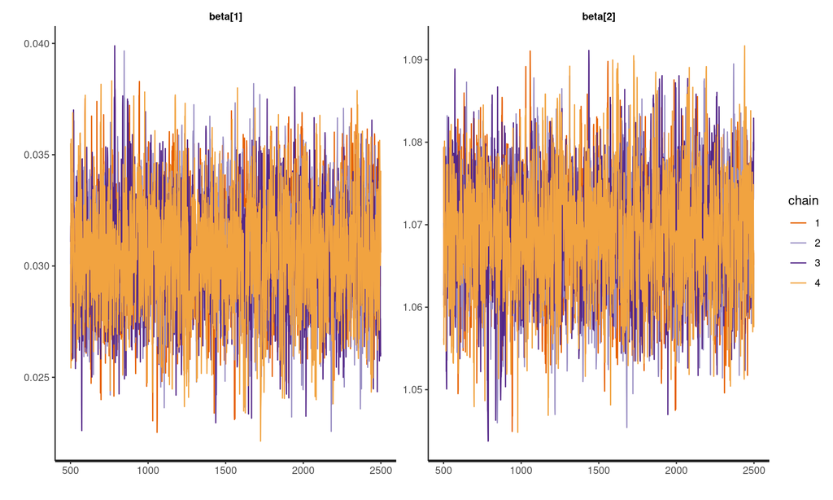

# Summary

- Summarize the fit

```r
print(model_fit, pars = c("beta","sigma"))
```

```
Inference for Stan model: anon_model.
4 chains, each with iter=2500; warmup=500; thin=1;
post-warmup draws per chain=2000, total post-warmup draws=8000.

        mean se_mean   sd 2.5%  25%  50%  75% 97.5% n_eff Rhat
beta[1] 0.03       0 0.00 0.03 0.03 0.03 0.03  0.04  3729    1
beta[2] 1.07       0 0.01 1.05 1.06 1.07 1.07  1.08  3462    1
sigma   0.06       0 0.00 0.06 0.06 0.06 0.06  0.06  3461    1

Samples were drawn using NUTS(diag_e) at Sun Oct  5 15:49:37 2025.
For each parameter, n_eff is a crude measure of effective sample size,
and Rhat is the potential scale reduction factor on split chains (at
convergence, Rhat=1).
```

# Summary

- Plot the results

```r
stan_plot(model_fit, pars = c("beta[2]"))
```

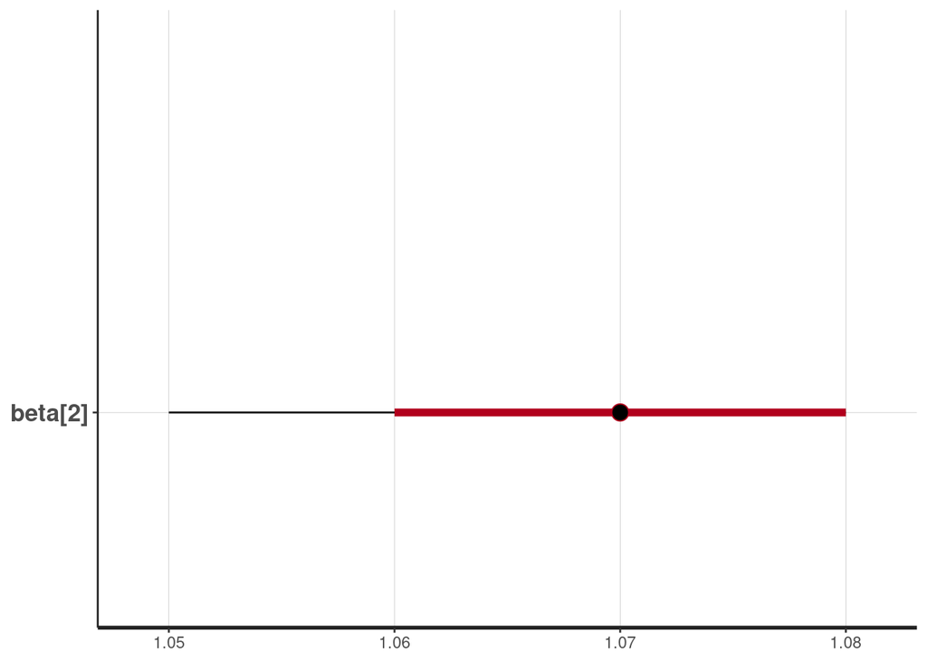

# Summary

- There’s cooler-looking stuff in `bayesplot`

```r
library(bayesplot)
```

```r
coef_plot <- mcmc_areas(model_fit, pars = c("beta[2]"))
coef_plot
```

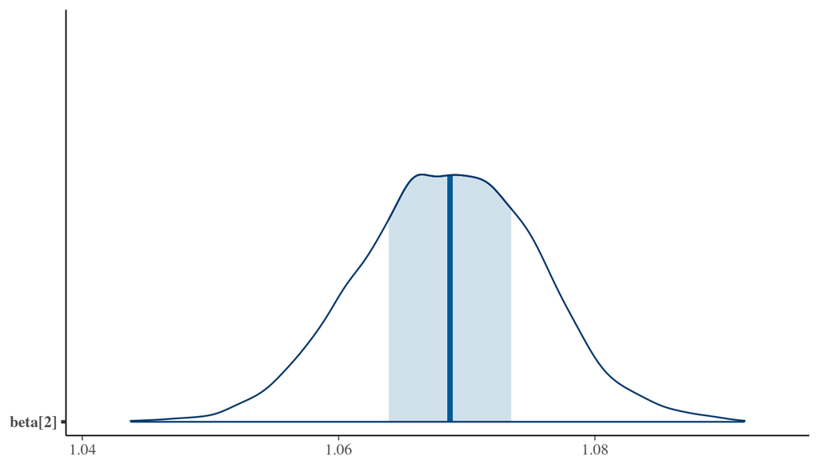

# Model diagnostics

# Posterior predictive distribution

- A very useful quantity to obtain is the **predictive** distribution of $y$ given the model.

  $$f(\tilde{y} | \mathbf{Y}) =\int f(\tilde{y}, \theta | \mathbf{Y}) d\theta = \int f(\tilde{y} | \mathbf{Y}, \theta) f(\theta | \mathbf{Y}) d\theta$$
- Suppose our prediction target is the in-sample distribution of the covariates
  - We can get the posterior predictive distribution directly from our MCMC algorithm by **drawing** a value of $y$ for each value of $\theta$ that we sample.
- (e.g.) for the logit

```stan
generated quantities {
  y_rep ~ bernoulli_logit_rng(X * beta); //generate coin flips for each sample
}
```

- It is common to use the posterior predictive distribution as a model diagnostic (“posterior predictive checking”)
  1. Check in-sample fit: Does the model actually reproduce the distribution of the data?
  2. Check against simulated data: Does the model recover the simulated distributions?

# Posterior predictive check

- Pull the `y_rep` from the model (in the form of a list)

```r
y_ppc <- rstan::extract(model_fit)$y_rep
```

- Calculate the upper and lower credible intervals

```r
y_ppc_ci <- t(apply(y_ppc, 2, function(x) quantile(x, c(.025, .975))))
```

- What’s the share that cover the truth?

```r
cover_95 <- y_ppc_ci[,1]<Y&Y<y_ppc_ci[,2]
mean(cover_95)
```

```
[1] 0.958
```

# Posterior predictive check

- What’s the root mean squared deviation from the truth?

```r
sqd_error <- apply((Y - t(y_ppc))^2, 2, mean)
print(sqrt(mean(sqd_error)))
```

```
[1] 0.0847
```

- Make a dataframe for the predictive “ribbon” plot

```r
elections_county$lowerppd <- y_ppc_ci[,1]
elections_county$upperppd <- y_ppc_ci[,2]
```

# Posterior predictive check

- Plot the posterior predictive intervals against the data

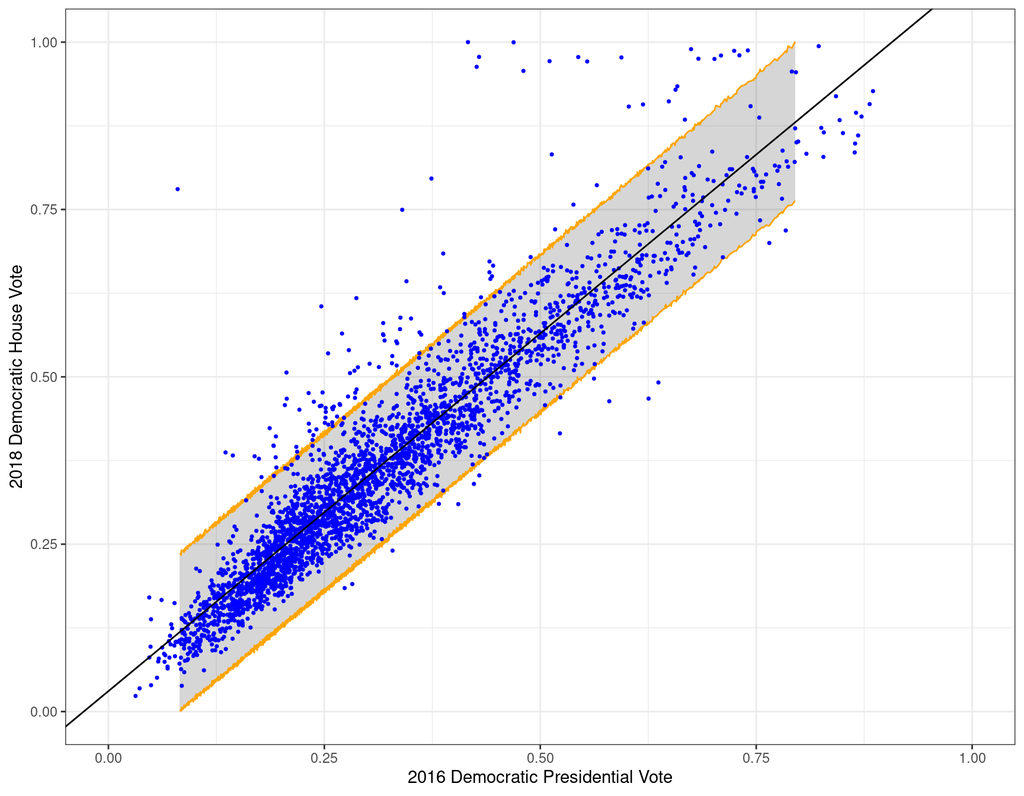

# Posterior predictive check

- Or plot the empirical density vs. the posterior predicted curves

```r
bayesplot::ppc_dens_overlay(y = elections_county$dem2018, yrep = y_ppc[1:25,])
```

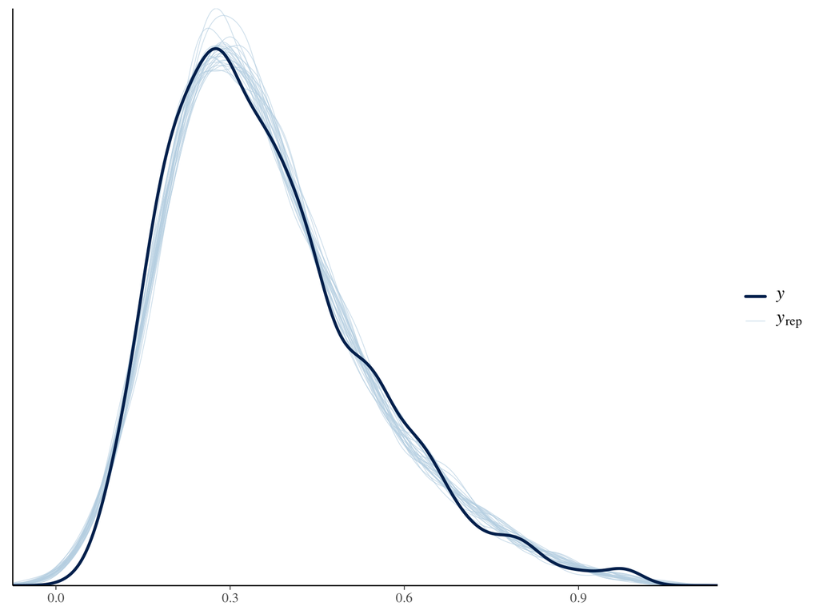

# Model Diagnostics

- There are two general approaches to evaluating model quality and comparing the predictive power of two or more statistical models given the same data
  - **Information criteria**
  - **Cross-validation**
- Both apporaches actually share common goals
  - **Reward** quality of predictions
  - **Penalize** model complexity
- We want to avoid models that **overfit** to the observed data
  - Information criteria address this with an explicit penalty term for the number of parameters
  - Cross-validation methods do this by evaluating fit on a “held-out” part of the data that’s not used to estimate the model.

# Information Criteria

- Frequentist/MLE Inference - the **Akaike Information Criterion**

  $$\text{AIC} = 2k - 2\ell(\hat{\theta})$$
  - $k$ is the number of parameters and $\ell(\hat{\theta})$ is the value of the maximized log-likelihood.
  - Pick the model with the **lowest** AIC
- Bayesian Inference - the **Deviance Information Criterion**

  $$\text{DIC} = 2p_{DIC} - 2\log p(y | \hat{\theta}_{\text{PM}})$$
  - $\hat{\theta}_{\text{PM}}$ is the posterior mean and
  - the “effective number of parameters” is $p_{DIC} = (\log p(y | \hat{\theta}_{\text{PM}}) - E_{\text{post}}[\log p(y|\theta)])$

# Log-predictive density

- In general, a very common objective function for evaluating the quality of model “fit” in a Bayesian setting is the **log-predictive density** or $\log p(y | \theta)$
  - Think of it as a more general version of criteria like “mean-squared error”
- For a new “out-of-sample” $\tilde{y}_i$, the posterior predictive distribution is

  $$\log p_{\text{post}} (\tilde{y}_i) = \log \int p(\tilde{y}_i | \theta) \times p_{\text{post}}(\theta)d\theta$$
- We want to pick a model that has a high **expected log pointwise-predictive density** – for a “new” size $n$ sample of observation drawn from a common distribution $f(\tilde{y}_i)$,

  $$\text{elppd} = \sum_{i=1}^n E_f[\log p_{\text{post}} (\tilde{y}_i)] = \sum_{i=1}^n\int \log p_{\text{post}} (\tilde{y}_i)f(\tilde{y}_i)d\tilde{y}_i$$
- Our goal is to try to estimate this from the data that we have.

# Estimating elppd

- One approach would be to use the “in-sample” fit criterion using in-sample observations $y_i$

$$\text{lppd} = \sum_{i=1}^n \log p_{\text{post}} (y_i)$$

- We can calculate it by averaging over our $S$ posterior samples

$$\widehat{\text{lppd}} = \sum_{i=1}^n \log \bigg( \frac{1}{S} \sum_{s=1}^S p(y_i | \theta^s)\bigg)$$

- But here we know that it’s going to be biased for the “out-of-sample” predictive error due to over-fitting.

# Estimating elppd

- An improvement would be to correct the “in-sample” fit using a measure of the model complexity
  - This is the intuition behind AIC, DIC, (and other information criteria like WAIC)
- An alternative would be to use **cross-validation**:
  - Split the sample into $K$ “folds” (typical choice is 10)
  - For each fold $k$, estimate the model on the $K-1$ other folds
  - Using that model, calculate the log-predictive density for the observations in the $k$th fold
  - The $k$th fold is the “held-out” (or “test” set), the $K-1$ remaining folds are the “training” set
- When $K = N$, this is often known as **“leave-one out” cross-validation**

# Leave-one-out CV

- From Vehtari, Gelman and Gabry (2017), our “leave-one-out” estimate of the expected log predictive density is:

$$\text{elpd}_{\text{loo}} = \sum_{i=1}^n \log p(y_i | y_{-i})$$

- In principle, this requires re-fitting the model to $N$ datasets (with a single observation removed). However, it is possible to obtain an estimate of $\log p(y_i | y_{-i})$ using the full model fit. Note:

$$p(y_i | y_{-i}) = \int p(y_i | \theta) p(\theta | y_{-i}) d\theta$$

- We can calculate $p(y_i | \theta)$ for a given draw of theta.
  - However, we only have draws from $p(\theta | y)$ (our posterior).
  - The solution is to re-weight our draws such that, averaging over them yields an integral over $p(\theta | y_{-i})$

# Leave-one-out CV

- Ultimately, we need to re-weight by $\frac{p(\theta_s | y_{-i})}{p(\theta_s | y)}$. Gelfand, Dey and Chang (1992) show that under conditional independence in the model:

  $$\frac{p(\theta_s | y_{-i})}{p(\theta_s | y)} = \frac{p(\theta_s | y_{-i})}{p(\theta_s | y_i, y_{-i})} \propto \frac{p(\theta_s | y_{-i})}{p(y_i | \theta_s)p(\theta_s | y_{-i})} = \frac{1}{p(y_i | \theta_s)}$$
- Let $r^s_i = \frac{1}{p(y_i | \theta^s)}$ or the importance weight calculated for monte carlo sample $s$
- Then our monte carlo estimate of $p(y_i | y_{-i})$ is

  $$p(y_i | y_{-i}) = \frac{\sum_{s=1}^S r_i^s p(y_i | \theta^s)}{\sum_{s=1}^S r_i^s}$$
- Unfortunately, these importance weights are very poorly behaved (high variance).
- Vehtari, Gelman and Gabry (2017) propose an alternative method for estimating the importance weights: **pareto-smoothed-importance-sampling** (PSIS)
  - Fit a Pareto distribution to the distribution of the importance ratio weights to stablize the variance of the weights.
- This PSIS-LOO cross-validation method is implemented in the `loo` R package.

# Leave-one-out CV

- In order to use `loo`, we need the log-likelihood evaluated at each observation. This comes by default in canned `rstanarm` or `brms` models but for custom models we need to specify to return it in the `generated quantities` block
- For the typical normal regression:

```stan
vector[N] log_lik;
for (n in 1:N) log_lik[n] = normal_lpdf(y[n] | X[n, ] * beta, sigma);
```

- But this will depend on the *actual* log-likelihood of the model

# Leave-one-out CV

- Once specified, we can obtain an estimate of the expected log predictive accuracy

```r
library(loo)
```

```r
loo_reg <- loo(model_fit, pars="log_lik")
loo_reg$estimates
```

```
         Estimate     SE
elpd_loo   4269.3 115.36
p_loo        10.7   3.06
looic     -8538.7 230.72
```